# The Growing ‘In-Between’

Paris Boo

2025-11-19

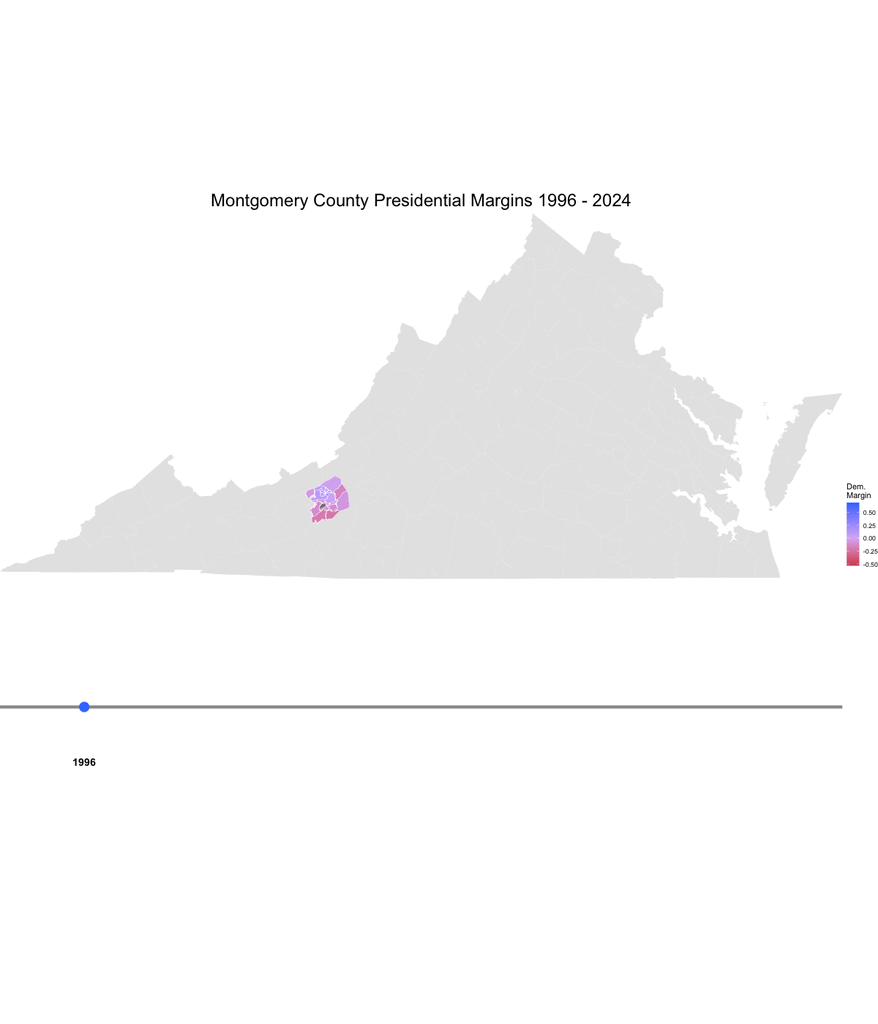

“In-betweenness.” This was a recurring theme in the texts we discussed in the postcolonialism and immigrant literature seminars I would organize as the English Department representative, back during my undergraduate years. Like many of the authors, I also grew up “in-between” cultures, having moved countries since childhood. In fact, my narrative is an embodiment of a bridge—connecting between disciplines and between policy and theory. Montgomery County, Virginia was where it all started.

My family lived in rural Virginia while my parents were completing their studies. Memories of my childhood in Virginia are some of my most vivid and cherished: be it of a family camping trip, or even the posters I would put up around my neighborhood to stop cars from running over squirrels. It did not matter that I was often the only Asian student in the classroom in my small elementary school. Back then I felt at home. My youthful innocence shielded me from any difficulties one may presumably encounter as a newcomer.

When our family moved back to Seoul, however, was when I realized how “in-between” I was: I could not even speak my mother tongue. In the years that followed, I learned to reconcile my Korean background with my Virginia upbringing. My life in Virginia shaped the trajectory of my life afterwards—as a bridge, mediating between differences.

I have been a bridge between disciplines. As a PhD student studying political polarization and immigration, interdisciplinary approaches are key to my research. In fact, in the past, when I was conducting research on public opinion on Korea’s compliance with the Nonproliferation Treaty, as a Nonproliferation Fellow at Korea Advanced Institute for Science and Technology (KAIST), my own research was enriched by the interdisciplinary perspectives from scholars in diverse fields. Knowing the synergy produced by interdisciplinary exchanges, I founded the first foreign affairs journal at Seoul National University’s Graduate School of International Studies, to provide a platform for my peers to connect with those outside their discipline.

I have been a bridge between different perspectives. Writing has thus always been a way for me to engage with those outside of my boundaries. For instance, when I became Editor-in-Chief of Seoul National University’s English Press, I gathered student volunteers to create an audio-version of the paper to make the paper more accessible, receiving the school’s social responsibility award as a result. As President of Seoul National University’s Student Ambassadors, I practiced cross-cultural communication, introducing Korea to an international audience.

Having been “in-between” cultures my entire life, I understand the importance of mediating differences and finding common ground.

It is somewhat ironic, in a bittersweet way, that the one place that taught me to reconcile differences, is seeing a divergence amongst its own community members. The graphic above shows the margins in voting results for Presidential Elections from 1996 to 2024 forr Montgomery County. As the years progress, my once-purple hometown increasingly becomes red and blue: evidence of partisan sorting and growing electoral polarization.